# Regression II

Dr. Liu Qizhang

1 October 2016

In the previous lesson, we have tried out regresion model and also learned methods of how to diagnose the model. As you have seen, very often, simply fitting the dependent variable with all independent variables does not always give reasonably good result. Indeed, most of time, it gives very poor fitting. In this lesson, we will discuss how to improve the model.

# Simple Method

From the *summary()* function, we can tell which independent variables are not linearly related to the the dependent variable. We may just consider removing them from the model. Let’s use ToyatoaCorolla data again.

```r
#read in data
cars<-read.csv("ToyotaCorolla.csv")
cars <- cars[,c(-4)]

fit <- lm(Price ~., data=cars)
summary(fit)
```

```
##
## Call:
## lm(formula = Price ~ ., data = cars)
##
## Residuals:
##      Min       1Q   Median       3Q      Max
## -12052.6   -765.8     -9.6    753.5   6236.4
##
## Coefficients:
##               Estimate Std. Error t value Pr(>|t|)
## (Intercept) -6.033e+03  1.005e+03  -6.005 2.42e-09 ***
## Age         -1.225e+02  2.623e+00 -46.684  < 2e-16 ***
## KM          -1.659e-02  1.293e-03 -12.829  < 2e-16 ***
## HP           3.275e+01  2.547e+00  12.860  < 2e-16 ***
## MetColor     3.654e+01  7.593e+01   0.481    0.630
## Automatic    1.942e+02  1.572e+02   1.235    0.217
## CC          -1.632e+00  2.810e-01  -5.806 7.88e-09 ***
## Doors       -5.704e+01  3.928e+01  -1.452    0.147
## Weight       2.255e+01  1.082e+00  20.845  < 2e-16 ***
## ---
## Signif. codes:  0 '***' 0.001 '**' 0.01 '*' 0.05 '.' 0.1 ' ' 1
##
## Residual standard error: 1334 on 1427 degrees of freedom
## Multiple R-squared:  0.8654, Adjusted R-squared:  0.8646
## F-statistic:  1147 on 8 and 1427 DF,  p-value: < 2.2e-16
```

You may find that MetColor, Automatic, and Doors are having p-value more than 0.1. Let’s try to remove them from the model.

```r
cars1 <- cars[,c(-5,-6,-8)]
fit1 <- lm(Price ~., data=cars1)
summary(fit1)
```

```
##
## Call:
## lm(formula = Price ~ ., data = cars1)
##
## Residuals:
##      Min       1Q   Median       3Q      Max
## -11992.2   -767.1    -16.8    769.2   6199.9
##
## Coefficients:
##               Estimate Std. Error t value Pr(>|t|)
## (Intercept) -6.000e+03  9.852e+02  -6.090 1.45e-09 ***
## Age         -1.221e+02  2.594e+00 -47.086  < 2e-16 ***
## KM          -1.682e-02  1.287e-03 -13.061  < 2e-16 ***
## HP           3.247e+01  2.540e+00  12.784  < 2e-16 ***
## CC          -1.626e+00  2.771e-01  -5.869 5.46e-09 ***
## Weight       2.235e+01  1.026e+00  21.781  < 2e-16 ***
## ---
## Signif. codes:  0 '***' 0.001 '**' 0.01 '*' 0.05 '.' 0.1 ' ' 1
##
## Residual standard error: 1335 on 1430 degrees of freedom
## Multiple R-squared:  0.865,  Adjusted R-squared:  0.8646
## F-statistic:  1833 on 5 and 1430 DF,  p-value: < 2.2e-16
```

This turns out to work very well. The model is simplified by removing three variables, yet the fitness of the model remains the same.

Let’s further diagnose the model using the methods indicated in the last lesson.

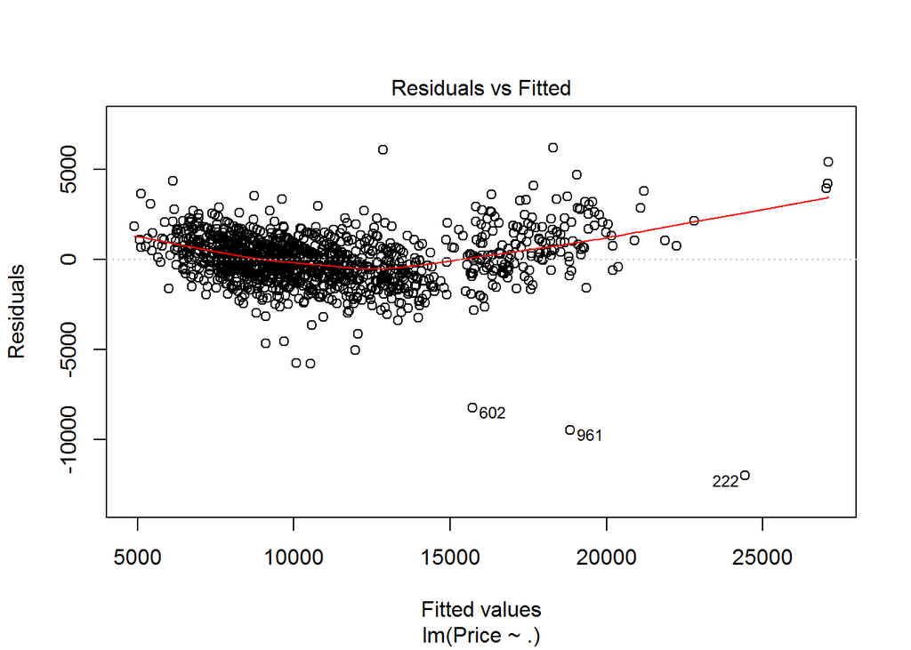

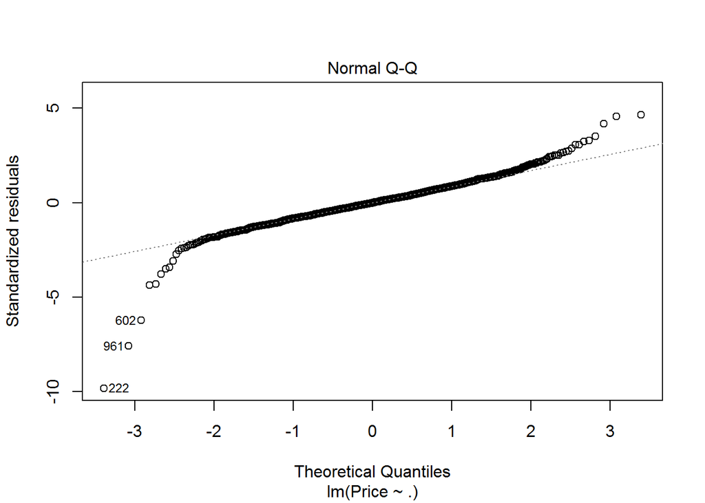

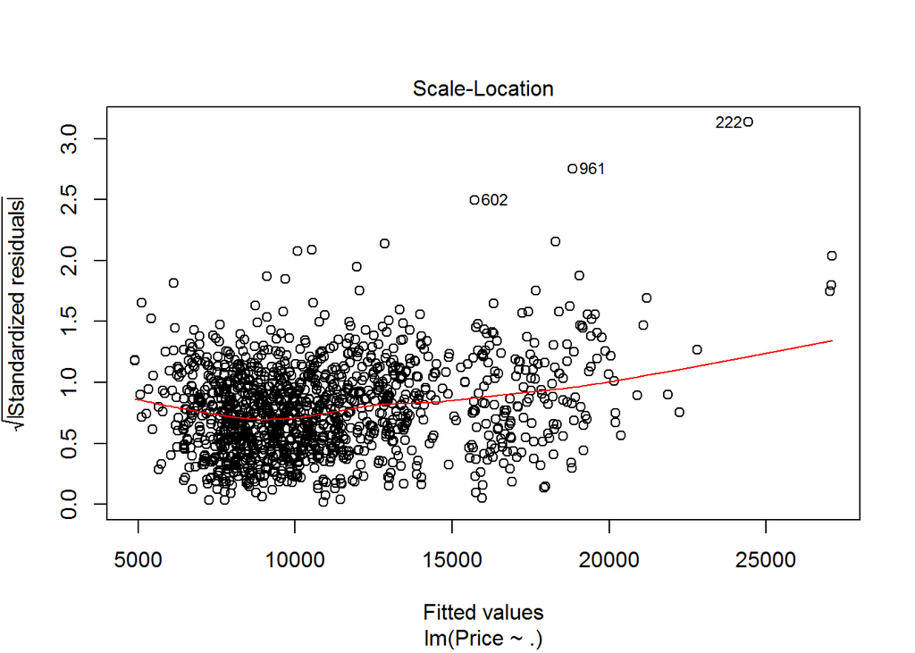

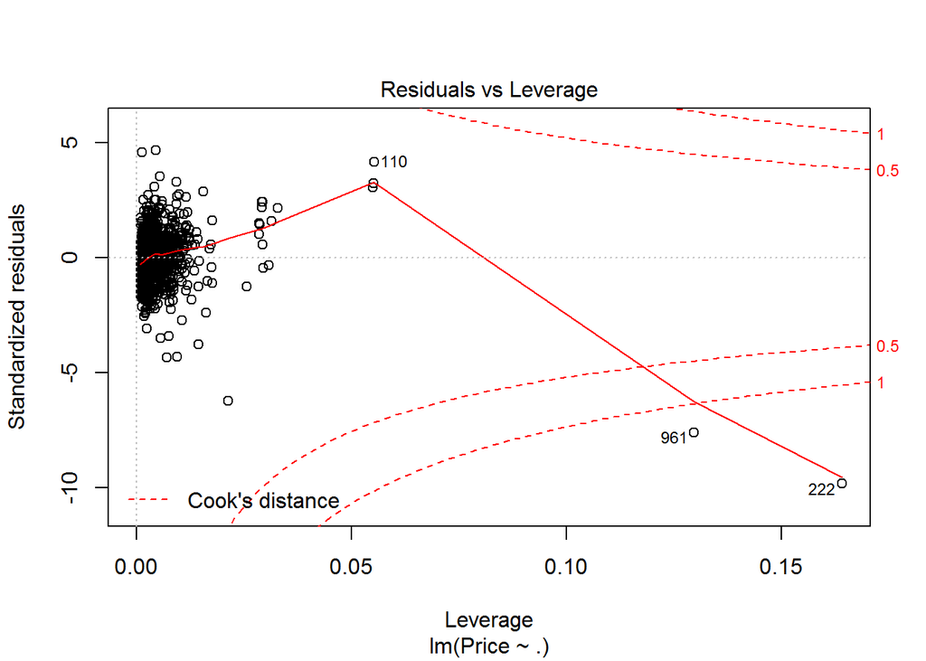

```r
plot(fit1)
```

We still can see some minor deviation from the statistical assumptions of linear regression in this model.

```r
library(car)
```

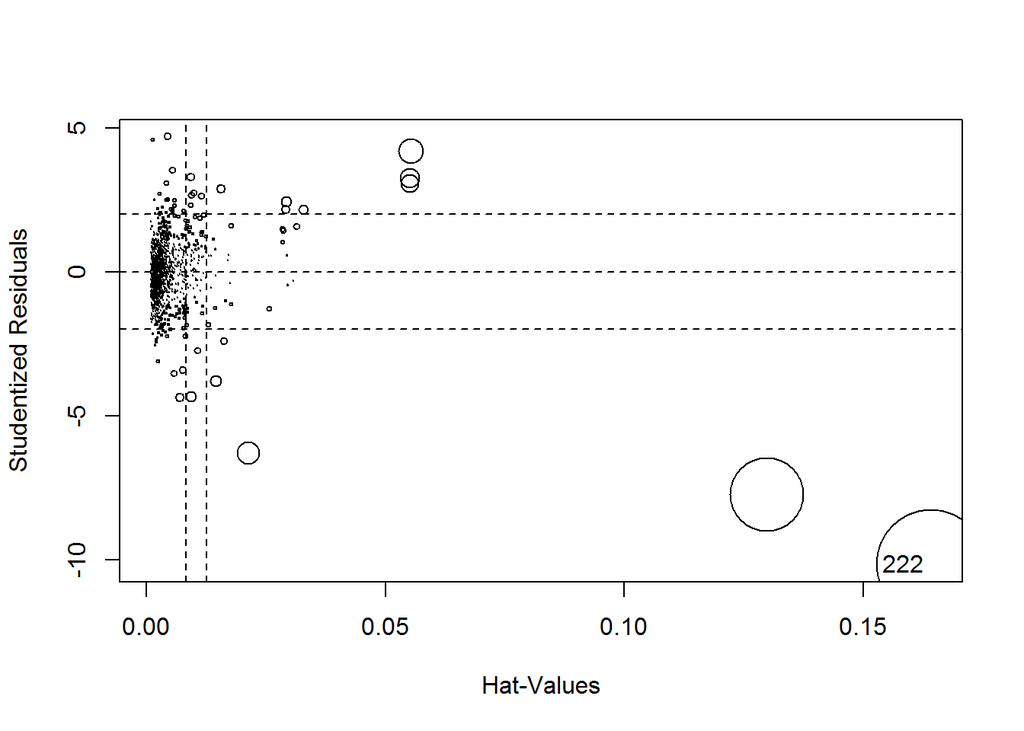

```
##       StudRes       Hat    CookD
## 222 -10.17268 0.1641344 3.160263
```

```r
influencePlot(fit1)
```

Some outliers can be identified. We may examine these outliers closely and identify some factors that make them outliers. If we are able to identify such factors, we can then try to introduce new variable(s) into the dataset and improve the model. Examining outliers sometimes turn out to very valuable. It may help to identify some insights unknown previously. However, if these outliers cannot be explained or sometimes purely due to data entry error, we may consider remove them from the model. Let’s have a try here:

```r
outlierTest(fit1)
```

```
##       rstudent unadjusted p-value Bonferonni p
## 222 -10.172682         1.6246e-23   2.3329e-20
## 961  -7.743730         1.8171e-14   2.6093e-11
## 602  -6.311282         3.6840e-10   5.2903e-07
## 148   4.689193         3.0049e-06   4.3150e-03
## 524   4.606997         4.4490e-06   6.3887e-03
## 193  -4.380017         1.2732e-05   1.8283e-02
## 192  -4.343369         1.5021e-05   2.1570e-02
## 110   4.184829         3.0278e-05   4.3480e-02
```

```r
cars2 <- cars1[c(-220,-961,-602,-148,-524,-193,-192,-110),]
fit2<-lm(Price ~., data=cars2)
summary(fit2)
```

```
##
## Call:
## lm(formula = Price ~ ., data = cars2)
##
## Residuals:
##      Min       1Q   Median       3Q      Max
## -13274.0   -760.2    -19.3    730.6   4733.1
##
## Coefficients:
##               Estimate Std. Error t value Pr(>|t|)
## (Intercept) -8.023e+03  9.983e+02  -8.037 1.92e-15 ***
## Age         -1.185e+02  2.485e+00 -47.683  < 2e-16 ***
## KM          -1.699e-02  1.212e-03 -14.018  < 2e-16 ***
## HP           2.995e+01  2.381e+00  12.581  < 2e-16 ***
## CC          -1.991e+00  2.690e-01  -7.401 2.30e-13 ***
## Weight       2.484e+01  1.058e+00  23.480  < 2e-16 ***
## ---
## Signif. codes:  0 '***' 0.001 '**' 0.01 '*' 0.05 '.' 0.1 ' ' 1
##
## Residual standard error: 1246 on 1422 degrees of freedom
## Multiple R-squared:  0.8776, Adjusted R-squared:  0.8772
## F-statistic:  2040 on 5 and 1422 DF,  p-value: < 2.2e-16
```

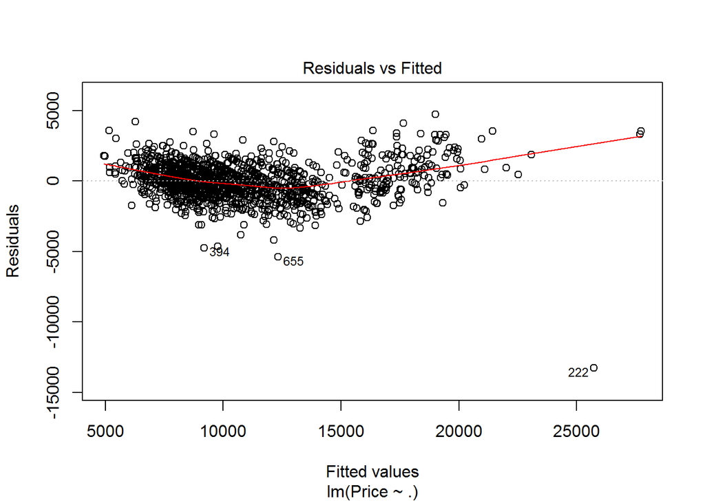

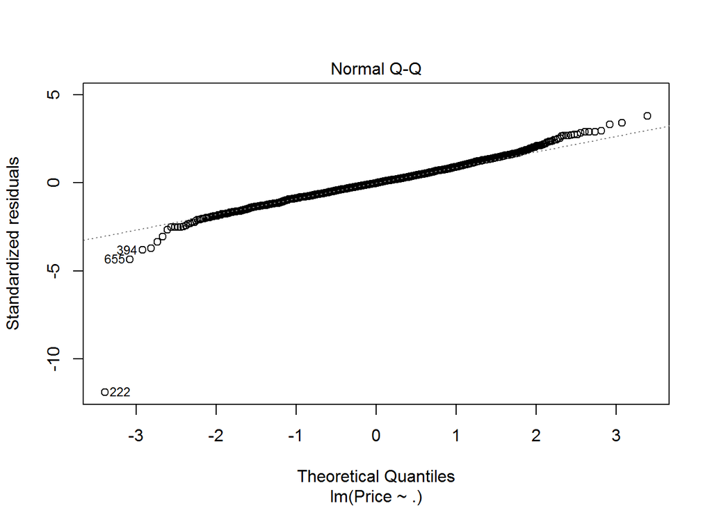

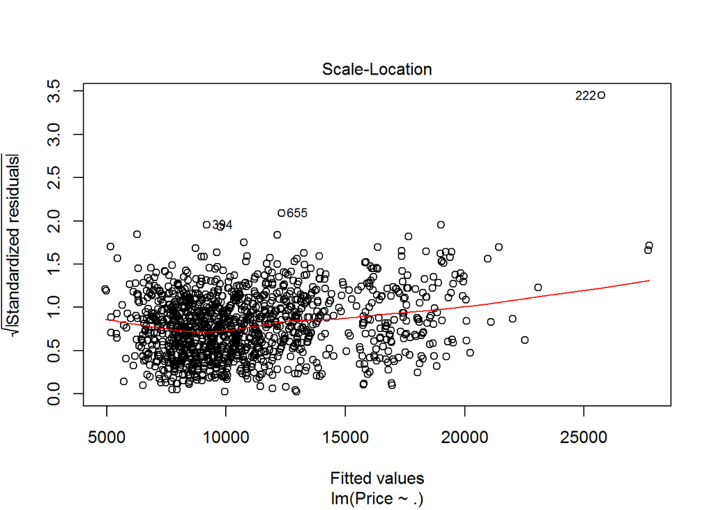

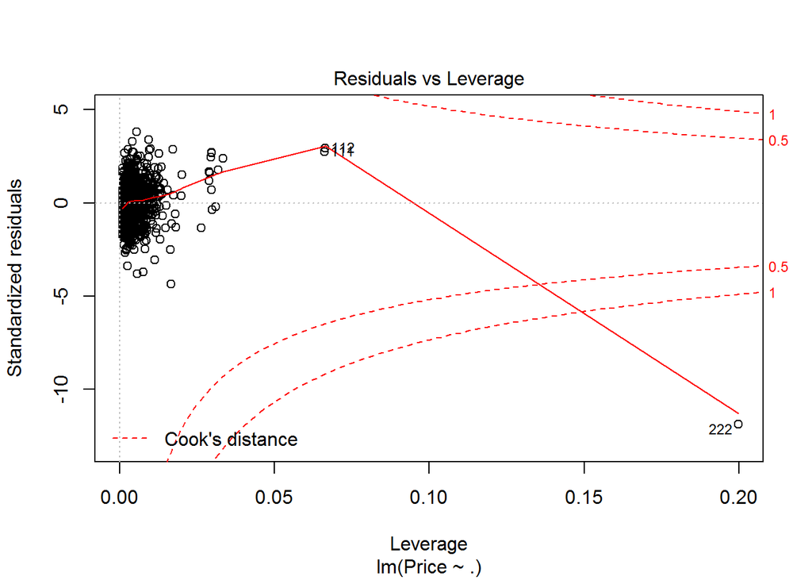

```r
plot(fit2)
```

```r
outlierTest(fit2)
```

```
##       rstudent unadjusted p-value Bonferonni p
## 222 -12.544293         2.6081e-34   3.7244e-31
## 655  -4.389028         1.2227e-05   1.7461e-02
```

As you can see, removing the outliers does improve the fitness a bit. Please compare the two models.

# Multicollinearity

To our common knowledge, for a second hand car, the older it is, more KM that it has travelled. Heavier a car is, more CC it should have. This can be validated from the correlation between them:

```r
cor(cars2$Age,cars2$KM)
```

```
## [1] 0.5073977
```

```r
cor(cars2$CC,cars2$Weight)
```

```
## [1] 0.6756669
```

In case two highly correlated variables are included in a model, it may be problematic. For example, it may make regression coefficients of these variables insignificant while they are supposed to be significant. Or it may lead to unreasonable interpretation of the coefficients. For example, the coefficient of CC is negative in the model, which means higher the CC is, cheaper the car is. Obviously this does not sound correct. The problem is called *multicollinearity*. Let’s see what happens if Weight is removed from the model.

```r
cars3<-cars2[,c(-6)]
fit3<-lm(Price~.,data=cars3)
summary(fit3)
```

```
##
## Call:
## lm(formula = Price ~ ., data = cars3)
##
## Residuals:
##     Min      1Q  Median      3Q     Max
## -4853.0  -929.1   -52.4   825.0 10469.5
##
## Coefficients:
##               Estimate Std. Error t value Pr(>|t|)
## (Intercept)  1.354e+04  4.606e+02  29.397   <2e-16 ***
## Age         -1.453e+02  2.598e+00 -55.927   <2e-16 ***
## KM          -1.708e-02  1.427e-03 -11.969   <2e-16 ***
## HP           3.009e+01  2.803e+00  10.732   <2e-16 ***
## CC           2.190e+00  2.375e-01   9.225   <2e-16 ***
## ---
## Signif. codes:  0 '***' 0.001 '**' 0.01 '*' 0.05 '.' 0.1 ' ' 1
##
## Residual standard error: 1468 on 1423 degrees of freedom
## Multiple R-squared:  0.8302, Adjusted R-squared:  0.8297
## F-statistic:  1740 on 4 and 1423 DF,  p-value: < 2.2e-16
```

*Multicollinearity* can be detected using a stastic called the *variance inflation factor (VIF)*. For any predicator variable, the square root of the VIF indicates the degree to which the confidence interval for the variable’s regression parameter is expanded relative to a model with uncorrelated predicators. As a general rule, *sqrt(vif)>2* indicates a multicollinearity problem.

```r
vif(fit2)
```

```
##      Age       KM       HP       CC   Weight
## 1.952424 1.886179 1.164443 2.316821 2.594238
```

```r
sqrt(vif(fit2)) > 2  #any problem?
```

```
##    Age     KM     HP     CC Weight
##  FALSE  FALSE  FALSE  FALSE  FALSE
```

The test tells no multicollinearity problem. Having correlated variables in a model is not a problem if your objective is just to predict the dependent variable. However, it will cause difficulty in explaining the variables.

# Variable selection

## Stepwise Regression

In stepwise selection, variables are added to or deleted from a model one at a time, until some stopping criteria is reached. For example, in *forward stepwise* regression, you add predictor variables to the model one at a time, until adding any variable no longer improves the model. In *backward stepwise* regression, you start with a model with all independent variables and delete predicator variables one at a time, until deleting any variable no longer improves the model. In *stepwise stepwise* regression, you combine the two approaches.

One stopping criterion used is the Akaike Information Criterion (AIC), which takes into account a model’s statistical fit and the number of parameters needed to achieve this fit. Models with smaller AIC values - indicating adequate fit with fewer parameters - are preferred. *MASS* package provides functions to perform variable selection using AIC.

```r
library(MASS)
stepAIC(fit, direction = "backward")
```

```
## Start:  AIC=20676.48
## Price ~ Age + KM + HP + MetColor + Automatic + CC + Doors + Weight
##
##             Df  Sum of Sq        RSS   AIC
## - MetColor   1     412403 2541217833 20675
## - Automatic  1    2715478 2543520908 20676
## <none>                    2540805430 20677
## - Doors      1    3754613 2544560042 20677
## - CC         1   60017724 2600823154 20708
## - KM         1  293055867 2833861297 20831
## - HP         1  294462106 2835267536 20832
## - Weight     1  773687942 3314493371 21056
## - Age        1 3880470157 6421275587 22006
##
## Step:  AIC=20674.72
## Price ~ Age + KM + HP + Automatic + CC + Doors + Weight
##
##             Df  Sum of Sq        RSS   AIC
## - Automatic  1    2688905 2543906738 20674
## <none>                    2541217833 20675
## - Doors      1    3598927 2544816760 20675
## - CC         1   59740271 2600958104 20706
## - KM         1  294157471 2835375304 20830
## - HP         1  295124259 2836342092 20831
## - Weight     1  773277564 3314495396 21054
## - Age        1 3898723709 6439941542 22008
##
## Step:  AIC=20674.23
## Price ~ Age + KM + HP + CC + Doors + Weight
##
##          Df  Sum of Sq        RSS   AIC
## <none>                 2543906738 20674
## - Doors   1    4020597 2547927335 20675
## - CC      1   64013515 2607920253 20708
## - HP      1  294781043 2838687781 20830
## - KM      1  301488154 2845394892 20833
## - Weight  1  816124104 3360030842 21072
## - Age     1 3947937486 6491844224 22018
```

```
##
## Call:
## lm(formula = Price ~ Age + KM + HP + CC + Doors + Weight, data = cars)
##
## Coefficients:
## (Intercept)          Age           KM           HP           CC
##  -6.183e+03   -1.221e+02   -1.676e-02    3.276e+01   -1.670e+00
##       Doors       Weight
##  -5.876e+01    2.277e+01
```

# Nonlinear factors

```r
fit4<-lm(Price~.^2+Age^2+KM^2+HP^2+Weight^2,data=cars)
summary(fit4)
```

```
##
## Call:
## lm(formula = Price ~ .^2 + Age^2 + KM^2 + HP^2 + Weight^2, data = cars)
##
## Residuals:
##     Min      1Q  Median      3Q     Max
## -7071.0  -694.0   -16.8   692.5  6947.6
##
## Coefficients:
##                      Estimate Std. Error t value Pr(>|t|)
## (Intercept)        -6.243e+04  1.314e+04  -4.749 2.25e-06 ***
## Age                 7.043e+02  7.778e+01   9.055  < 2e-16 ***
## KM                 -1.276e-01  3.279e-02  -3.892 0.000104 ***
## HP                  5.361e+01  9.487e+01   0.565 0.572066
## MetColor            1.426e+03  2.087e+03   0.683 0.494588
## Automatic          -8.013e+03  6.147e+03  -1.304 0.192598
## CC                  1.550e+01  5.937e+00   2.611 0.009117 **
## Doors               5.652e+02  1.244e+03   0.454 0.649543
## Weight              7.334e+01  1.341e+01   5.468 5.38e-08 ***
## Age:KM              4.170e-04  6.274e-05   6.647 4.29e-11 ***
## Age:HP             -1.217e+00  2.225e-01  -5.469 5.35e-08 ***
## Age:MetColor       -1.382e+01  5.094e+00  -2.712 0.006771 **
## Age:Automatic       9.474e+00  1.376e+01   0.689 0.491127
## Age:CC              4.306e-02  2.005e-02   2.148 0.031899 *
## Age:Doors           7.410e+00  2.681e+00   2.764 0.005781 **
## Age:Weight         -7.549e-01  7.711e-02  -9.789  < 2e-16 ***
## KM:HP               1.056e-04  7.625e-05   1.385 0.166334
## KM:MetColor         5.949e-03  2.349e-03   2.532 0.011435 *
## KM:Automatic        1.444e-03  5.824e-03   0.248 0.804248
## KM:CC              -1.120e-05  8.444e-06  -1.327 0.184754
## KM:Doors           -2.317e-03  1.302e-03  -1.780 0.075282 .
## KM:Weight           9.268e-05  3.815e-05   2.429 0.015251 *
## HP:MetColor         1.055e+01  4.699e+00   2.246 0.024865 *
## HP:Automatic       -1.401e+02  1.382e+02  -1.013 0.311075
## HP:CC               2.296e-02  4.334e-02   0.530 0.596370
## HP:Doors           -3.751e+00  2.500e+00  -1.501 0.133678
## HP:Weight          -7.606e-03  8.657e-02  -0.088 0.930003
## MetColor:Automatic -2.106e+02  2.930e+02  -0.719 0.472302
## MetColor:CC         2.956e-01  5.449e-01   0.543 0.587511
## MetColor:Doors     -9.730e+01  7.384e+01  -1.318 0.187810
## MetColor:Weight    -2.020e+00  2.307e+00  -0.875 0.381569
## Automatic:CC        8.369e+00  1.056e+01   0.792 0.428346
## Automatic:Doors    -1.800e+02  1.783e+02  -1.009 0.313093
## Automatic:Weight    9.558e+00  6.539e+00   1.462 0.144056
## CC:Doors            1.318e-01  2.913e-01   0.452 0.651035
## CC:Weight          -1.747e-02  5.387e-03  -3.244 0.001209 **
## Doors:Weight       -4.323e-01  1.310e+00  -0.330 0.741515
## ---
## Signif. codes:  0 '***' 0.001 '**' 0.01 '*' 0.05 '.' 0.1 ' ' 1
##
## Residual standard error: 1144 on 1399 degrees of freedom
## Multiple R-squared:  0.9031, Adjusted R-squared:  0.9006
## F-statistic:   362 on 36 and 1399 DF,  p-value: < 2.2e-16
```

As you can see, introducing some nonlinear factors do improve the fitness a bit. Let’s try to simplify it:

```r
stepAIC(fit4, direction="backward")
```

```
## Start:  AIC=20261.23
## Price ~ (Age + KM + HP + MetColor + Automatic + CC + Doors +
##     Weight)^2 + Age^2 + KM^2 + HP^2 + Weight^2
##
##                      Df Sum of Sq        RSS   AIC
## - HP:Weight           1     10097 1829995456 20259
## - KM:Automatic        1     80387 1830065746 20259
## - Doors:Weight        1    142374 1830127733 20259
## - CC:Doors            1    267743 1830253103 20259
## - HP:CC               1    367088 1830352447 20260
## - MetColor:CC         1    385075 1830370434 20260
## - Age:Automatic       1    620425 1830605784 20260
## - MetColor:Automatic  1    676095 1830661454 20260
## - Automatic:CC        1    821034 1830806393 20260
## - MetColor:Weight     1   1002141 1830987500 20260
## - Automatic:Doors     1   1332027 1831317386 20260
## - HP:Automatic        1   1343186 1831328545 20260
## - MetColor:Doors      1   2271342 1832256701 20261
## - KM:CC               1   2303112 1832288471 20261
## - KM:HP               1   2508452 1832493812 20261
## <none>                            1829985359 20261
## - Automatic:Weight    1   2794661 1832780021 20261
## - HP:Doors            1   2945611 1832930970 20262
## - KM:Doors            1   4144783 1834130142 20263
## - Age:CC              1   6034314 1836019673 20264
## - HP:MetColor         1   6598060 1836583419 20264
## - KM:Weight           1   7719902 1837705261 20265
## - KM:MetColor         1   8389187 1838374546 20266
## - Age:MetColor        1   9620337 1839605696 20267
## - Age:Doors           1   9994717 1839980076 20267
## - CC:Weight           1  13761266 1843746625 20270
## - Age:HP              1  39125122 1869110482 20290
## - Age:KM              1  57785843 1887771202 20304
## - Age:Weight          1 125348350 1955333709 20354
##
## Step:  AIC=20259.23
## Price ~ Age + KM + HP + MetColor + Automatic + CC + Doors + Weight +
##     Age:KM + Age:HP + Age:MetColor + Age:Automatic + Age:CC +
##     Age:Doors + Age:Weight + KM:HP + KM:MetColor + KM:Automatic +
##     KM:CC + KM:Doors + KM:Weight + HP:MetColor + HP:Automatic +
```

[output cut: 341 more lines]

```
## - Age:Automatic     1   3284885 1842140398 20247
## - HP:Doors          1   3369524 1842225037 20247
## - Automatic:Weight  1   3521276 1842376788 20247
## - HP:Automatic      1   3605000 1842460513 20247
## - KM:HP             1   3951211 1842806724 20247
## - MetColor:Doors    1   3959721 1842815234 20247
## - KM:Weight         1   5925701 1844781214 20249
## - HP:MetColor       1   6778902 1845634415 20250
## - Age:MetColor      1  10204281 1849059794 20252
## - KM:MetColor       1  10918436 1849773948 20253
## - Age:Doors         1  11526735 1850382247 20253
## - CC:Weight         1  14988472 1853843984 20256
## - Age:KM            1  64009721 1902865234 20293
## - Age:HP            1  71058925 1909914438 20299
## - Age:Weight        1 153293379 1992148892 20359
```

```
##
## Call:
## lm(formula = Price ~ Age + KM + HP + MetColor + Automatic + CC +
##     Doors + Weight + Age:KM + Age:HP + Age:MetColor + Age:Automatic +
##     Age:CC + Age:Doors + Age:Weight + KM:HP + KM:MetColor + KM:Doors +
##     KM:Weight + HP:MetColor + HP:Automatic + HP:Doors + MetColor:Doors +
##     Automatic:Weight + CC:Weight, data = cars)
##
## Coefficients:
##      (Intercept)               Age                KM                HP
##       -5.972e+04         6.655e+02        -1.048e-01         8.602e+01
##         MetColor         Automatic                CC             Doors
##       -2.956e+02        -7.126e+03         1.652e+01         3.167e+02
##           Weight            Age:KM            Age:HP      Age:MetColor
##        6.616e+01         4.164e-04        -1.216e+00        -1.192e+01
##    Age:Automatic            Age:CC         Age:Doors        Age:Weight
##        1.599e+01         2.182e-02         6.603e+00        -6.855e-01
##            KM:HP       KM:MetColor          KM:Doors         KM:Weight
##        1.246e-04         5.929e-03        -1.622e-03         5.050e-05
##      HP:MetColor      HP:Automatic          HP:Doors    MetColor:Doors
##        1.046e+01        -2.760e+01        -3.833e+00        -1.200e+02
## Automatic:Weight         CC:Weight
##        8.737e+00        -1.568e-02
```

Let’s evaluate the final model:

```r
fit5<-lm(formula = Price ~ Age + KM + HP + MetColor + Automatic + CC +
     Doors + Weight + Age:KM + Age:HP + Age:MetColor + Age:Automatic +
     Age:CC + Age:Doors + Age:Weight + KM:HP + KM:MetColor + KM:Doors +
     KM:Weight + HP:MetColor + HP:Automatic + HP:Doors + MetColor:Doors +
     Automatic:Weight + CC:Weight, data = cars)
summary(fit5)
```

```
##
## Call:
## lm(formula = Price ~ Age + KM + HP + MetColor + Automatic + CC +
##     Doors + Weight + Age:KM + Age:HP + Age:MetColor + Age:Automatic +
##     Age:CC + Age:Doors + Age:Weight + KM:HP + KM:MetColor + KM:Doors +
##     KM:Weight + HP:MetColor + HP:Automatic + HP:Doors + MetColor:Doors +
##     Automatic:Weight + CC:Weight, data = cars)
##
## Residuals:
##     Min      1Q  Median      3Q     Max
## -7396.9  -685.9   -16.1   676.1  6882.8
##
## Coefficients:
##                    Estimate Std. Error t value Pr(>|t|)
## (Intercept)      -5.972e+04  1.031e+04  -5.791 8.63e-09 ***
## Age               6.655e+02  6.809e+01   9.774  < 2e-16 ***
## KM               -1.048e-01  2.759e-02  -3.801 0.000150 ***
## HP                8.602e+01  1.028e+01   8.371  < 2e-16 ***
## MetColor         -2.956e+02  6.126e+02  -0.482 0.629545
## Automatic        -7.126e+03  5.583e+03  -1.276 0.202072
## CC                1.652e+01  5.270e+00   3.134 0.001760 **
## Doors             3.167e+02  2.889e+02   1.096 0.273133
## Weight            6.616e+01  9.294e+00   7.118 1.73e-12 ***
## Age:KM            4.164e-04  5.943e-05   7.006 3.79e-12 ***
## Age:HP           -1.216e+00  1.648e-01  -7.382 2.66e-13 ***
## Age:MetColor     -1.192e+01  4.262e+00  -2.797 0.005224 **
## Age:Automatic     1.599e+01  1.008e+01   1.587 0.112721
## Age:CC            2.182e-02  1.435e-02   1.521 0.128587
## Age:Doors         6.603e+00  2.221e+00   2.973 0.002999 **
## Age:Weight       -6.855e-01  6.323e-02 -10.842  < 2e-16 ***
## KM:HP             1.246e-04  7.159e-05   1.741 0.081971 .
## KM:MetColor       5.929e-03  2.049e-03   2.893 0.003869 **
## KM:Doors         -1.622e-03  1.139e-03  -1.424 0.154755
## KM:Weight         5.050e-05  2.369e-05   2.132 0.033212 *
## HP:MetColor       1.046e+01  4.588e+00   2.280 0.022763 *
## HP:Automatic     -2.760e+01  1.660e+01  -1.663 0.096614 .
## HP:Doors         -3.833e+00  2.385e+00  -1.607 0.108194
## MetColor:Doors   -1.200e+02  6.887e+01  -1.742 0.081642 .
## Automatic:Weight  8.737e+00  5.317e+00   1.643 0.100568
## CC:Weight        -1.568e-02  4.626e-03  -3.390 0.000718 ***
## ---
## Signif. codes:  0 '***' 0.001 '**' 0.01 '*' 0.05 '.' 0.1 ' ' 1
##
## Residual standard error: 1142 on 1410 degrees of freedom
## Multiple R-squared:  0.9026, Adjusted R-squared:  0.9009
## F-statistic: 522.6 on 25 and 1410 DF,  p-value: < 2.2e-16
```

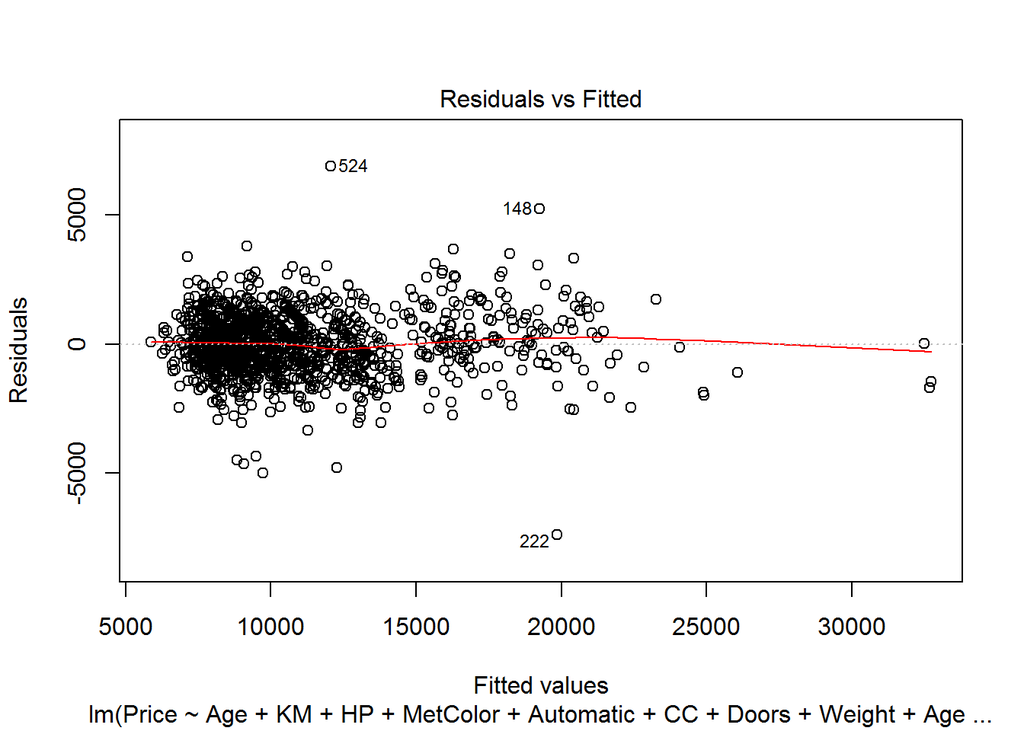

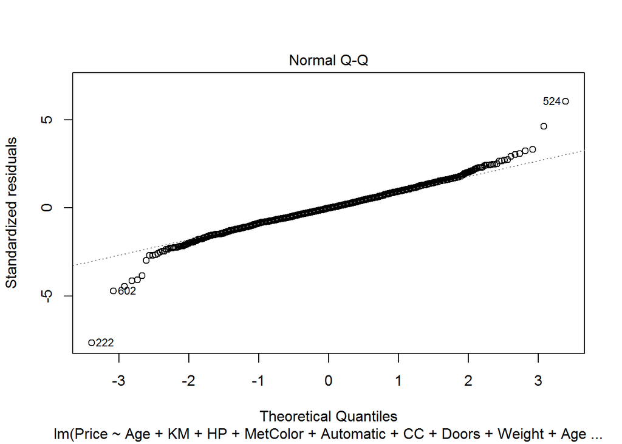

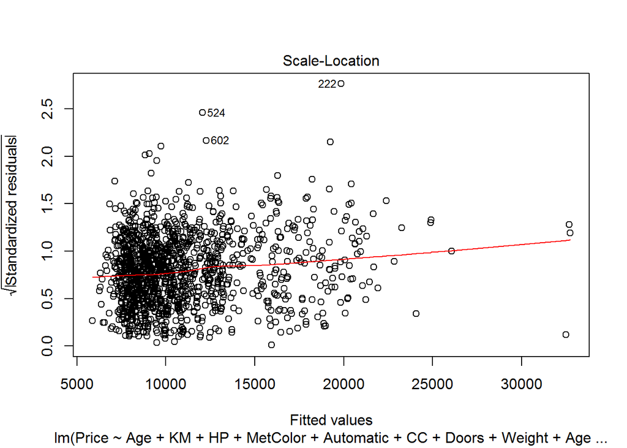

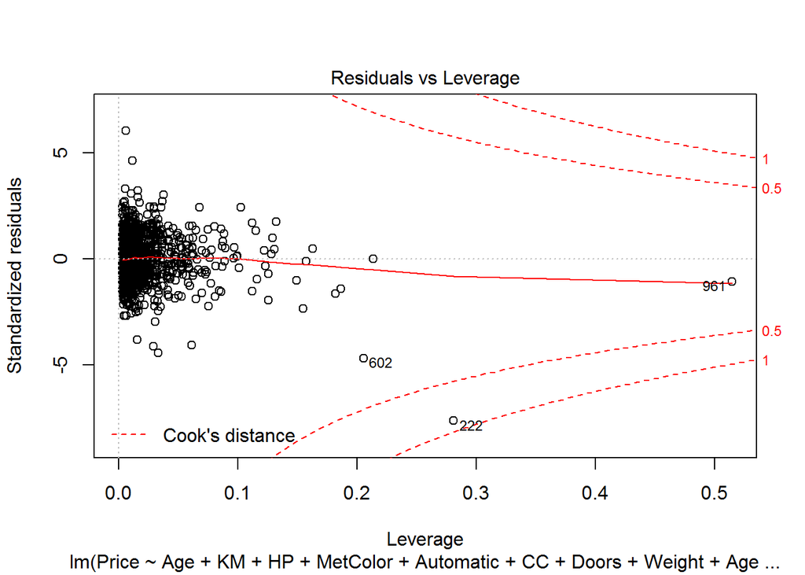

```r
plot(fit5)
```

Please comment on fi5 vs fit.

Exercise: We have ignored “FuelType” in our analysis so far. Does it have an impact in the model? How to incorporate this factor in our model?

# Cross Validation

So far, our focus has been on deriving a model that could be used to interpret the relationship between dependent variable and the independent variables. However, if your ultimate objective is prediction, then you should care more about the performance of the model in predicting new data. In this section, we are going to introduce a method called *Cross-Validation* to evaluate the generalizability of a regression equation.

In Cross-Validation, a portion of the data is selected as the training sample, and a portion is selected as the hold-out sample. A regression model is developed on the training sample, and then applied to the hold-out sample to validate its performance.

In *k-fold cross-validation*, the sample is divided into *k* subsamples. Each of the *k* subsamples serves as a hold-out group, and the combined observations from the remaining *k-1* subsamples serve as the training group. The preformance for the *k* prediction equations applied to the *k* hold out samples is recorded and then averaged.

The following function can be used for this purpose:

```r
shrinkage <- function(fit, k=10){
    require(bootstrap)
    theta.fit <- function(x,y) {lsfit(x,y)}
    theta.predict<-function(fit, x) {cbind(1,x) %*%fit$coef}

    x<-fit$model[,2:ncol(fit$model)]
    y<-fit$model[,1]
    results<-crossval(x,y,theta.fit,theta.predict,ngroup=k)
    r2<-cor(y,fit$fitted.values)^2
    r2cv<-cor(y,results$cv.fit)^2
    cat("Original R-square =", r2, "\n")
    cat(k, "Fold Cross-Validated R-Square = ",r2cv,"\n")
    cat("Change =", r2-r2cv,"\n")
}
```

Now, let’s compare the models done above:

```r
shrinkage(fit)
```

```
## Original R-square = 0.8654038
## 10 Fold Cross-Validated R-Square =  0.8585361
## Change = 0.006867646
```

```r
shrinkage(fit1)
```

```
## Original R-square = 0.8650265
## 10 Fold Cross-Validated R-Square =  0.8591982
## Change = 0.005828336
```

```r
shrinkage(fit5)
```

```
## Original R-square = 0.9025888
## 10 Fold Cross-Validated R-Square =  0.8575093
## Change = 0.04507942
```

Please comment on the results.

# Relative Importance

A common question that a manager will ask is “What is the most important factor in the model?” It is quite obvious that we cannot use the coefficients. The simplest approach has been to compare standardized regression coeeficients, which describe the expected chaneg in the response variable (expressed in standard deviation units) for a standard deviation change in a predictor variable, holding the other variables constant. You can obtain the standardized regression coefficient in R by standardizing each of the variables in your dataset to a mean of 0 and standard deviation of 1 using the *scale()* function, before submitting the dataset to a regression analysis. For example,

```r
zcars1 <- as.data.frame(scale(cars1))
zfit<-lm(Price~.,data=zcars1)
coef(zfit)
```

```
##   (Intercept)           Age            KM            HP            CC
## -1.012096e-15 -6.262975e-01 -1.738937e-01  1.341007e-01 -8.393559e-02
##        Weight
##  3.243686e-01
```

You can see that “Age” is the most important factor in deciding the resale price of Toyota Corolla. A one-standard-deviation increase in car age will decrease the car price by 0.626 standard deviation.